# Text Mining en Don Quijote de La Mancha

#### 8.1 UPOS (Universal Part Of Speech)

```r
# Tabla de UPOS ordenada en orden creciente.

table(data_udpipe_anotado$upos)[order(table(data_udpipe_anotado$upos))]
```

```
##
##   SYM  PART CCONJ PROPN   ADP   NUM SCONJ     X   AUX  PRON   DET   ADV   ADJ
##    17    37  1149  1162  1335  2502  3442  3645  4116  5510  5953  6340 43210
##  VERB  NOUN
## 48374 54739
```

Los nombres, verbos y adjetivos son las palabras más utilizadas en ese orden.La tabla no muestra completamente la realidad, ya que hemos realizado una limpieza anterior del texto eliminando los adverbios y preposiciones más comunes.

Mostramos en gráfico la tabla anterior.

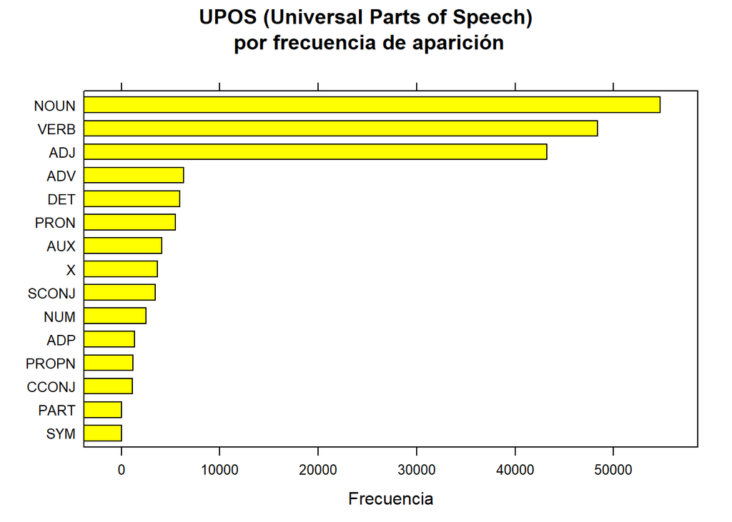

```r
#ESTADISTICAS BASICAS DE FRECUENCIA

## UPOS

# Creamos un data.frame con la función txt_freq que crea una tabla a partir de x,
# en este primer caso los valores de upos, con la frecuencia
stats_upos     <- txt_freq(data_udpipe_anotado$upos)

# Convertimos key en factor, ordenados de forma inversa
stats_upos$key <- factor(stats_upos$key, levels = rev(stats_upos$key))

# Pasamos los datos al gráfico
barchart(key ~ freq, data = stats_upos, col = "yellow",
         main = "UPOS (Universal Parts of Speech)\n por frecuencia de aparición",
         xlab = "Frecuencia")
```

#### 8.2 Nombres más frecuentes

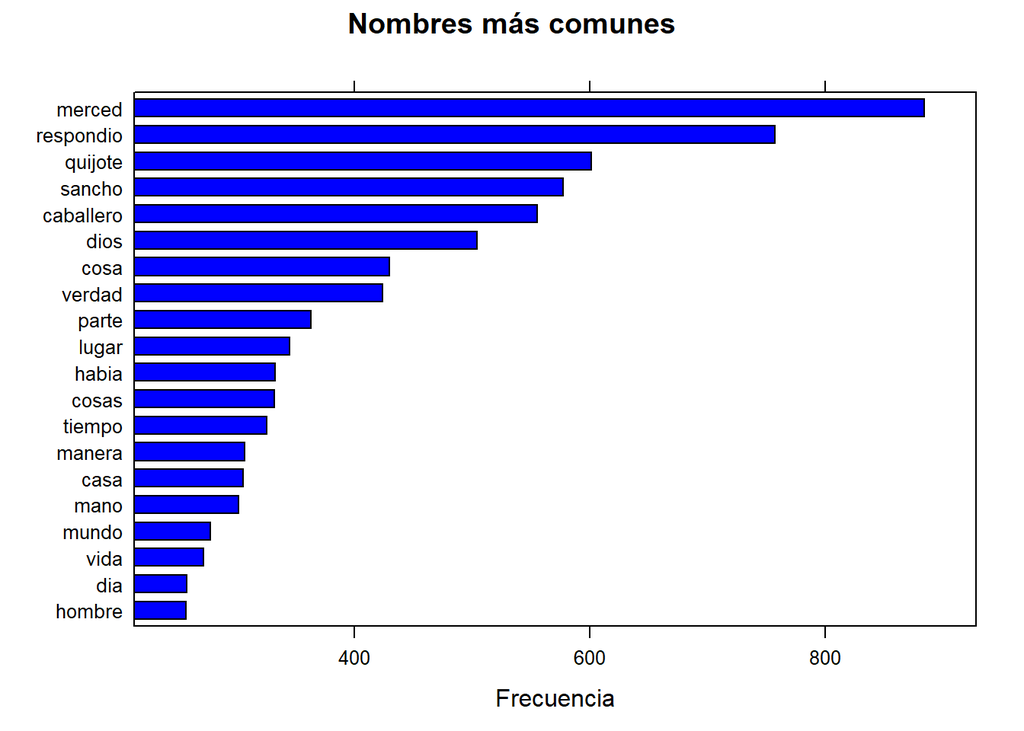

```r
## Nombres

# En este caso, primero vamos a crear un objeto, stats_nombres, con los valores
# NOUN en data_udpipe_anotado
stats_nombres     <- subset(data_udpipe_anotado, upos %in% c("NOUN"))

# Y ahora, con txt_freq, sacamos la frecuencia de cada nombre
stats_nombres     <- txt_freq(stats_nombres$token)

# Convertimos key en factor, ordenados de forma inversa
stats_nombres$key <- factor(stats_nombres$key, levels = rev(stats_nombres$key))

# El gráfico
barchart(key ~ freq, data = head(stats_nombres, 20), col = "blue",
         main = "Nombres más comunes", xlab = "Frecuencia")
```

Podemos apreciar que los nombres más frecuentes son merced, quijote, sancho, caballero. El segundo en este caso es respondió, que es un verbo, quizá está mal clasificado por haber anulado los acentos de las palabras.

#### 8.3 Adjetivos más comunes

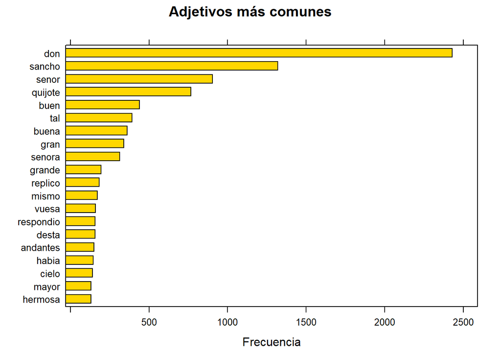

```r
## Adjetivos

# Como el caso anterior, primero obtenemos los adjetivos
stats_adjetivos     <- subset(data_udpipe_anotado, upos %in% c("ADJ"))

# Y ahora, con txt_freq, sacamos la frecuencia de cada nombre
stats_adjetivos     <- txt_freq(stats_adjetivos$token)

# Convertimos key en factor, ordenados de forma inversa
stats_adjetivos$key <- factor(stats_adjetivos$key, levels = rev(stats_adjetivos$key))

# El gráfico
barchart(key ~ freq, data = head(stats_adjetivos, 20), col = "gold",
         main = "Adjetivos más comunes", xlab = "Frecuencia")
```

#### 8.4 verbos más frecuentes

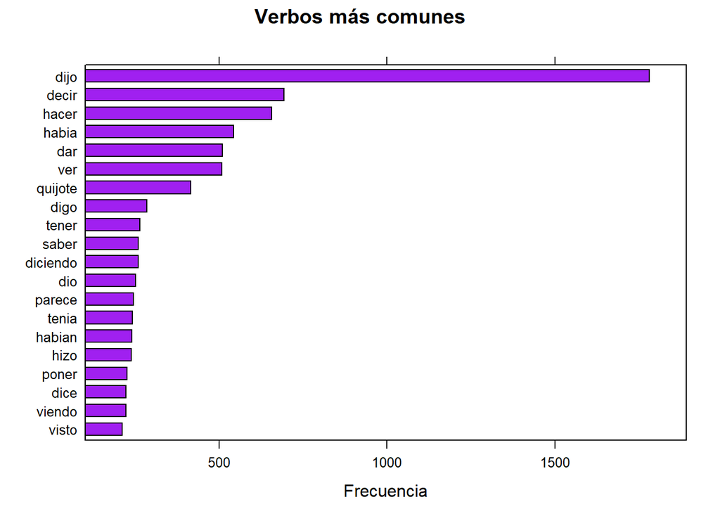

```r
# Verbos

# Como el caso anterior, primero obtenemos los verbos
stats_verbos     <- subset(data_udpipe_anotado, upos %in% c("VERB"))

# Y ahora, con txt_freq, sacamos la frecuencia de cada nombre
stats_verbos     <- txt_freq(stats_verbos$token)

# Convertimos key en factor, ordenados de forma inversa
stats_verbos$key <- factor(stats_verbos$key, levels = rev(stats_verbos$key))

# El gráfico
barchart(key ~ freq, data = head(stats_verbos, 20), col = "purple",
         main = "Verbos más comunes", xlab = "Frecuencia")
```

Los verbos nos pueden dar una idea del tipo de acción que contiene el texto, en este caso dá a entender que se cuenta una historia debido a los tiempos verbales usados y las referencias al verbo decir.

### 9. RAKE (Rapid Automatic Keyword Extraction algorithm)

Utilizaremos ahora el algoritmo RAKE para extraer las palabras clave y hacer una asociación entre ellas.

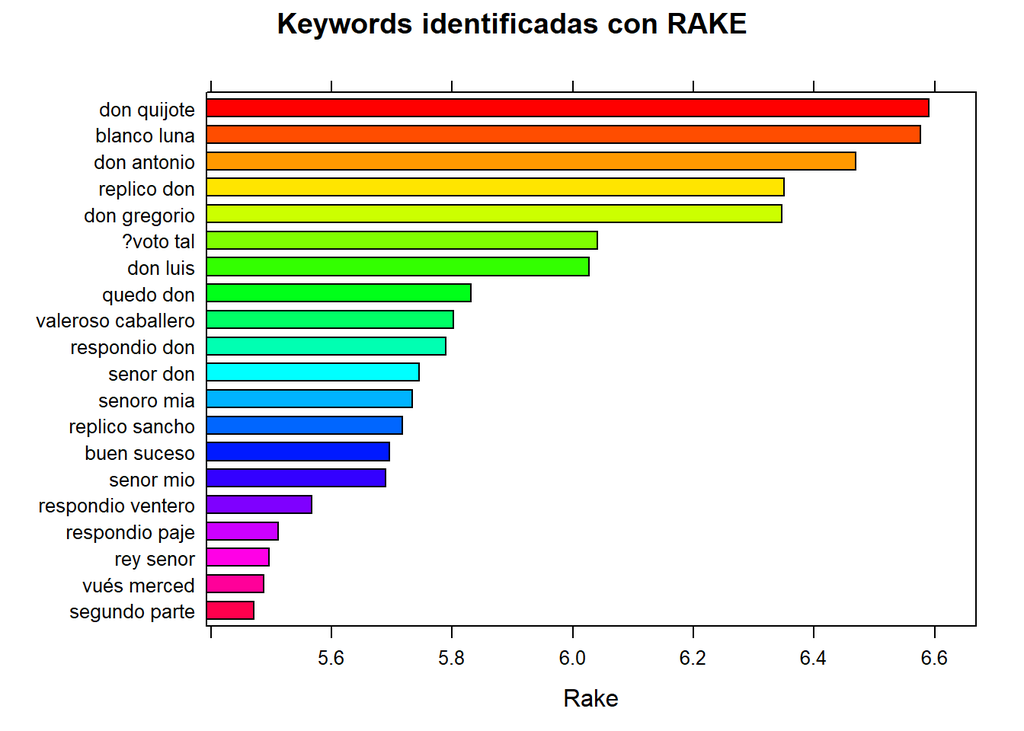

```r
## Usando RAKE

stats_rake     <- keywords_rake(x        = data_udpipe_anotado,
                                # la columna con textos a buscar, lemma
                                term     = "lemma",
                                # el id
                                group    = "doc_id",
                                relevant = data_udpipe_anotado$upos %in% c("NOUN", "ADJ"))

# Convertimos key en factor, ordenados de forma inversa
stats_rake$key <- factor(stats_rake$keyword, levels = rev(stats_rake$keyword))

# El gráfico
barchart(key ~ rake, data = head(subset(stats_rake, freq > 3), 20), col = rainbow(20),
         main = "Keywords identificadas con RAKE",
         xlab = "Rake")
```

El algoritmo nos deja muestras que las palabras más repetidas son algunos de los personajes, con algunos de sus adjetivos. Como Don Quijote, blanco luna, Don Antonio.

### 10. COLLOCATION

Palabras seguidas unas de otras

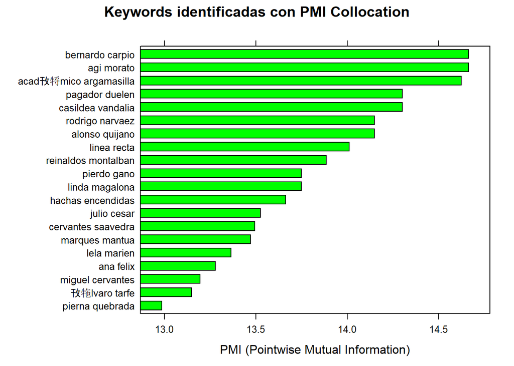

```r
# Usando Collocation con Pointwise Mutual Information (PMI)

# Y ahora con la función keywords_collocation buscamos las keywords. Primero le
# pasamos el data.frame, data_udpipe_anotado
stats_keywords_collocation     <- keywords_collocation(x     = data_udpipe_anotado,
                                                       term  = "token",
                                                       group = "doc_id")

# Convertimos key en factor, ordenados de forma inversa
stats_keywords_collocation$key <- factor(stats_keywords_collocation$keyword,
                                         levels = rev(stats_keywords_collocation$keyword))

# El gráfico con una frecuencia mayor de 4, los 20 primeros
barchart(key ~ pmi, data = head(subset(stats_keywords_collocation, freq > 4), 20),
         col  = "green",
         main = "Keywords identificadas con PMI Collocation",
         xlab = "PMI (Pointwise Mutual Information)")
```

Vemos que las combinaciones más repetidas suelen ser el nombre de un protagonista y su apellido.

### 11. CO-OCCURRENCES:

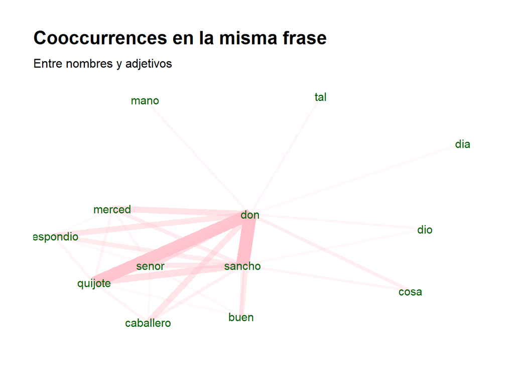

```r
# Nos quedamos sólo con los nombres y los adjetivos
data_udpipe_anotado_noun_adj             <- subset(data_udpipe_anotado, upos %in% c("NOUN", "ADJ"))

# Pasamos el id a número
data_udpipe_anotado_noun_adj$doc_id      <- as.integer(data_udpipe_anotado_noun_adj$doc_id)

# Primero pasamos el data.frame, data_udpipe_anotado_noun_adj
cooc <- cooccurrence(data_udpipe_anotado_noun_adj,

                     # Buscamos en la columna lemma
                     term  = "lemma",

                     # Los id de las columnas sobre las que se buscarán las
                     # coincidencias
                     group = c("doc_id", "paragraph_id", "sentence_id"))

# Como están ordenadas, nos quedamos con las 30 primeras
wordnetwork <- head(cooc, 30)

# Creamos el gráfico con la función graph_from_data_frame
wordnetwork <- graph_from_data_frame(wordnetwork)

# El gráfico
ggraph(wordnetwork, layout = "fr") +
  geom_edge_link(aes(width = cooc, edge_alpha = cooc), edge_colour = "pink") +
  geom_node_text(aes(label = name), col = "darkgreen", size = 4) +
  theme_graph(base_family = "Arial Narrow") +
  theme(legend.position = "none") +
  labs(title = "Cooccurrences en la misma frase", subtitle = "Entre nombres y adjetivos")
```

Se aprecia como Don Quijote, Don Sancho, Sancho Caballero, o don señor son algunas de las combinaciones que más ocurren en la misma frase.

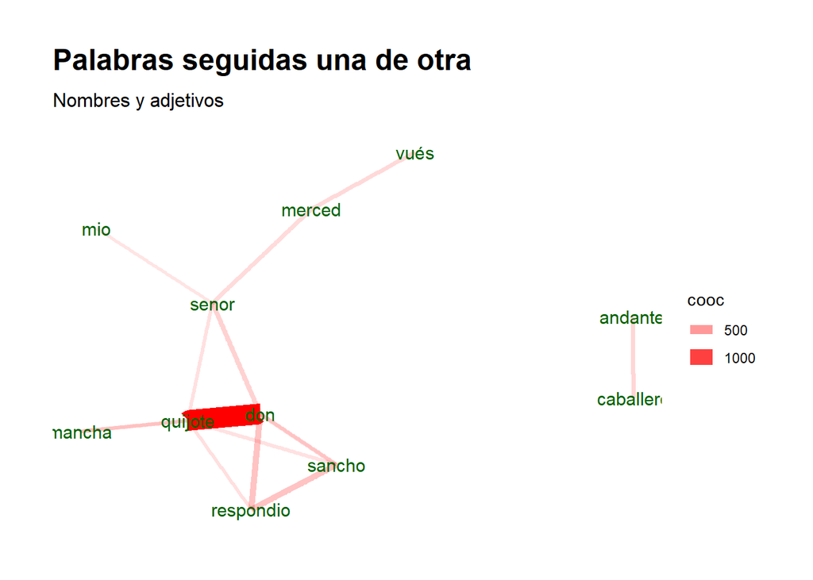

```r
# Nombres y adjetivos que siguen uno a otro
# En este caso incluimos el valor relevant para quedarnos con nombres y adjetivos
cooc2 <- cooccurrence(data_udpipe_anotado$lemma,
                      relevant = data_udpipe_anotado$upos %in% c("NOUN", "ADJ"),
                      skipgram = 1)

# Nos quedamos con las 15 primeras
wordnetwork <- head(cooc2, 15)

# Generamos los datos para el gráfico
wordnetwork <- graph_from_data_frame(wordnetwork)

# El gráfico
ggraph(wordnetwork, layout = "fr") +
  geom_edge_link(aes(width = cooc, edge_alpha = cooc),edge_colour = "red") +
  geom_node_text(aes(label = name), col = "darkgreen", size = 4) +
  theme_graph(base_family = "Arial Narrow") +
  labs(title = "Palabras seguidas una de otra", subtitle = "Nombres y adjetivos")
```

Destacan como palabras seguidas unas de otras, por un lado “Don Quijote”, y por otro “andante caballero”

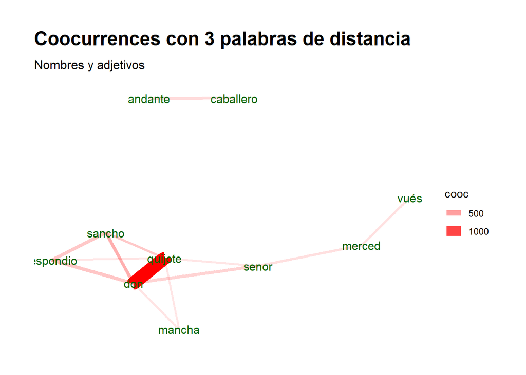

```r
# Nombres y adjetivos frecuencia aún saltando 2 palabras
# En este caso incluimos el valor relevant para quedarnos con nombres y adjetivos
cooc3 <- cooccurrence(data_udpipe_anotado$lemma,
                      relevant = data_udpipe_anotado$upos %in% c("NOUN", "ADJ"),
                      skipgram = 3)

# Nos quedamos con las 15 primeras
wordnetwork <- head(cooc3, 15)

# Generamos los datos para el gráfico
wordnetwork <- graph_from_data_frame(wordnetwork)

# El gráfico
ggraph(wordnetwork, layout = "fr") +
  geom_edge_link(aes(width = cooc, edge_alpha = cooc),edge_colour = "red") +
  geom_node_text(aes(label = name), col = "darkgreen", size = 4) +
  theme_graph(base_family = "Arial Narrow") +
  labs(title = "Coocurrences con 3 palabras de distancia", subtitle = "Nombres y adjetivos")
```

En este caso hemos probado con un salto de 3 palabras y aún asi siguen siendo estas las palabras, más seguidas unas de otras, igual que el analisis anterior.

### 12. PHRASES:

Secuencia de Parts Of Speech Tags

[figure not shown]

```r
## Detección de secuencias de partes del texto dentro de la frase con POS tags (nombres y verbos)

# Creamos una columna nueva, phrase_tag, con la función as_phrasemachine
# Básicamente revisa todos del POS y los reagrupa asignando una letra:
# A: adjective
# C: coordinating conjuction
# D: determiner
# M: modifier of verb
# N: noun or proper noun
# P: preposition
# O: other elements
data_udpipe_anotado$phrase_tag <- as_phrasemachine(data_udpipe_anotado$upos,
                                                   type = "upos")

# Ahora la función keywords_phrases obtiene frases en vez de combinaciones de
# dos palabras
stats_keywords_frases <- keywords_phrases(x        = data_udpipe_anotado$phrase_tag,

                                          # El término a buscar, token en minúsculas
                                          term     = tolower(data_udpipe_anotado$token),

                                          # Patrón de búsqueda con expresiones
                                          # regulares
                                          pattern  = "(A|N)+N(P+D*(A|N)*N)*",

                                          # Hay que poner en TRUE si pattern
                                          # es una expresión regular
                                          is_regex = TRUE,


                                          # detailed = FALSE cuenta el número de
                                          # veces que aparece la frase
                                          detailed = FALSE)
stats_keywords_frases <- subset(stats_keywords_frases, ngram > 3 & freq > 3)

# Convertimos key en factor, ordenados de forma inversa
stats_keywords_frases$key <- factor(stats_keywords_frases$keyword,
                                    levels = rev(stats_keywords_frases$keyword))

# El gráfico
barchart(key ~ freq, data = head(stats_keywords_frases, 20), col = rainbow(20),
         main = "Keywords - Frases simples de 4 palabras", xlab = "Frecuencia")
```

### 13. Red de palabras Text Rank

Red de palabras ordenadas con el algoritmo de Google. Muestra las palabras relevantes, que junto con otras relevantes, se combinan obteniendo palabras clave.

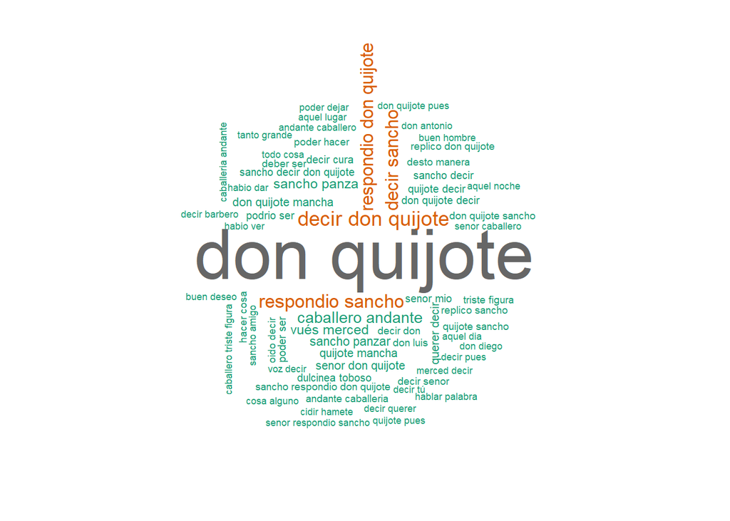

```r
palabras_textrank <- textrank_keywords(data_udpipe_anotado$lemma,
                          relevant = data_udpipe_anotado$upos %in% c("NOUN", "ADJ"),
                          ngram_max = 8, sep = " ")
palabras_textrank <- subset(palabras_textrank$keywords, ngram > 1 & freq >= 10)

# library(wordcloud)
wordcloud(words = palabras_textrank$keyword, freq = palabras_textrank$freq,
          random.order = FALSE, colors = brewer.pal(name = "Dark2", n = 8))
```